# Ćw6

Artur

2024-11-12

##Wczytanie plików FASTQ**

```r
library(ShortRead)
fq_reads1 <- readFastq("/Users/arturbalicki/Desktop/Studia/Magisterskie/ecoli_simulated1_with_adapters.fq")
fq_reads2 <- readFastq("/Users/arturbalicki/Desktop/Studia/Magisterskie/ecoli_simulated2_with_adapters.fq")
```

## Przycinanie odczytów na podstawie jakości**

1. Przytnij bazy o niskiej jakości z końców odczytów:

```r
 # Przycinanie odczytów forward
   trimmed_reads1 <- trimTailw(fq_reads1, k = 2, a = "B", halfwidth = 1)

   # Przycinanie odczytów reverse
   trimmed_reads2 <- trimTailw(fq_reads2, k = 2, a = "B", halfwidth = 1)
```

2. Sprawdź, ile odczytów zostało przyciętych:

```r
length(fq_reads1)
```

```
## [1] 309440
```

```r
length(trimmed_reads1)
```

```
## [1] 284123
```

```r
length(fq_reads2)
```

```
## [1] 309440
```

```r
length(trimmed_reads2)
```

```
## [1] 273668
```

```r
sum(width(trimmed_reads1) < width(fq_reads1))
```

```
## [1] 232479
```

```r
sum(width(trimmed_reads2) < width(fq_reads2))
```

```
## [1] 265053
```

- Przytnij odczyty i zanotuj, jaki procent odczytów został zmodyfikowany.

```r
Seq1<-284123/309440*100
Seq2<-273668/309440*100
print(Seq1)
```

```
## [1] 91.81845
```

```r
print (Seq2)
```

```
## [1] 88.43976
```

##Filtracja odczytów o niskiej jakości**

1. Filtrowanie odczytów (minimalna akceptowalna długość odczytu=50bp:

```r
   # Filtrowanie odczytów forward
   filtered_reads1 <- trimmed_reads1[width(trimmed_reads1) >= 50]

   # Filtrowanie odczytów reverse
   filtered_reads2 <- trimmed_reads2[width(trimmed_reads2) >= 50]
```

2. Sprawdź liczbę odczytów przed i po filtracji:

```r
   # Odczyty forward
   length(trimmed_reads1)       # Po przycinaniu
```

```
## [1] 284123
```

```r
   length(filtered_reads1)      # Po filtracji
```

```
## [1] 248565
```

```r
   # Odczyty reverse
   length(trimmed_reads2)
```

```
## [1] 273668
```

```r
   length(filtered_reads2)
```

```
## [1] 223516
```

- Oblicz, jaki procent odczytów został odrzucony podczas filtracji.

```r
Seq1f<-248565/284123*100
print(Seq1f)
```

```
## [1] 87.485
```

```r
Seq2f<-223516/273668*100
print(Seq2f)
```

```
## [1] 81.67415
```

##Ponowna kontrola jakości po przycinaniu i filtracji**

1. Zapisz przetworzone odczyty do nowych plików FASTQ:

```r
   writeFastq(filtered_reads1, "/Users/arturbalicki/Desktop/Studia/Magisterskie/ecoli_simulated1_processed.fq")
   writeFastq(filtered_reads2, "/Users/arturbalicki/Desktop/Studia/Magisterskie/ecoli_simulated2_processed.fq")
```

2. Wygeneruj nowe raporty QC dla przetworzonych danych:

```r
qa_results1 <- qa("/Users/arturbalicki/Desktop/Studia/Magisterskie/ecoli_simulated1_with_adapters.fq", type = "fastq")
qa_results1_processed <- qa( "/Users/arturbalicki/Desktop/Studia/Magisterskie/ecoli_simulated1_processed.fq", type = "fastq")
report(qa_results1, dest = "/Users/arturbalicki/Desktop/Studia/Magisterskie/QA_report_read1")
```

```
## [1] "/Users/arturbalicki/Desktop/Studia/Magisterskie/QA_report_read1/index.html"
```

```r
report(qa_results1_processed, dest = "/Users/arturbalicki/Desktop/Studia/Magisterskie/QA_report_read1_processed")
```

```
## [1] "/Users/arturbalicki/Desktop/Studia/Magisterskie/QA_report_read1_processed/index.html"
```

```r
qa_results2 <- qa("/Users/arturbalicki/Desktop/Studia/Magisterskie/ecoli_simulated2_with_adapters.fq", type = "fastq")
qa_results2_processed <- qa("/Users/arturbalicki/Desktop/Studia/Magisterskie/ecoli_simulated2_processed.fq", type = "fastq")
report(qa_results2, dest = "/Users/arturbalicki/Desktop/Studia/Magisterskie/QA_report_read2")
```

```
## [1] "/Users/arturbalicki/Desktop/Studia/Magisterskie/QA_report_read2/index.html"
```

```r
report(qa_results2_processed, dest = "/Users/arturbalicki/Desktop/Studia/Magisterskie/QA_report_read2_processed")
```

```
## [1] "/Users/arturbalicki/Desktop/Studia/Magisterskie/QA_report_read2_processed/index.html"
```

## Analiza rozkładu długości odczytów**

1. Porównaj rozkład długości odczytów przed i po przycinaniu:

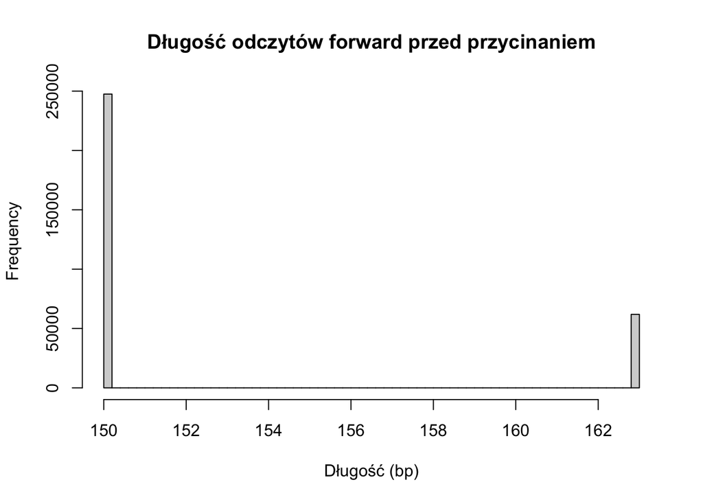

```r
   # Przed przycinaniem (odczyty forward)
   hist(width(fq_reads1), breaks = 50, main = "Długość odczytów forward przed przycinaniem", xlab = "Długość (bp)")
```

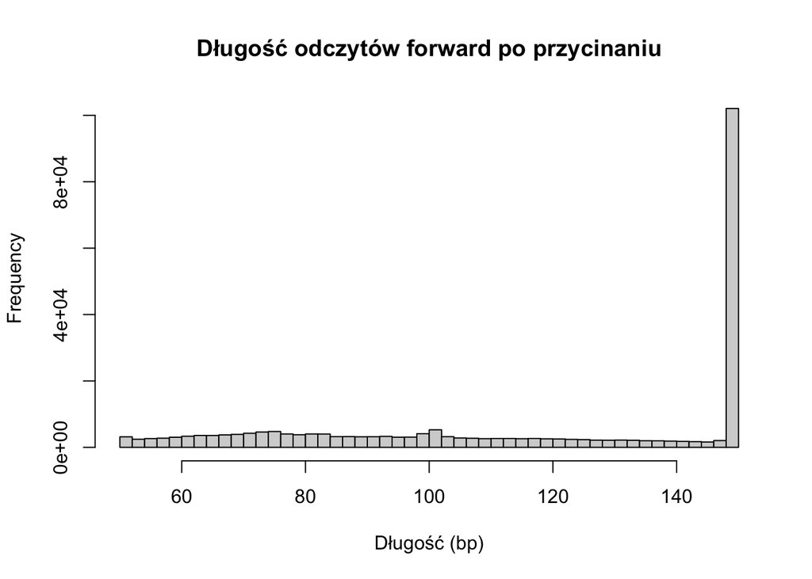

```r
   # Po przycinaniu (odczyty forward)
   hist(width(filtered_reads1), breaks = 50, main = "Długość odczytów forward po przycinaniu", xlab = "Długość (bp)")
```

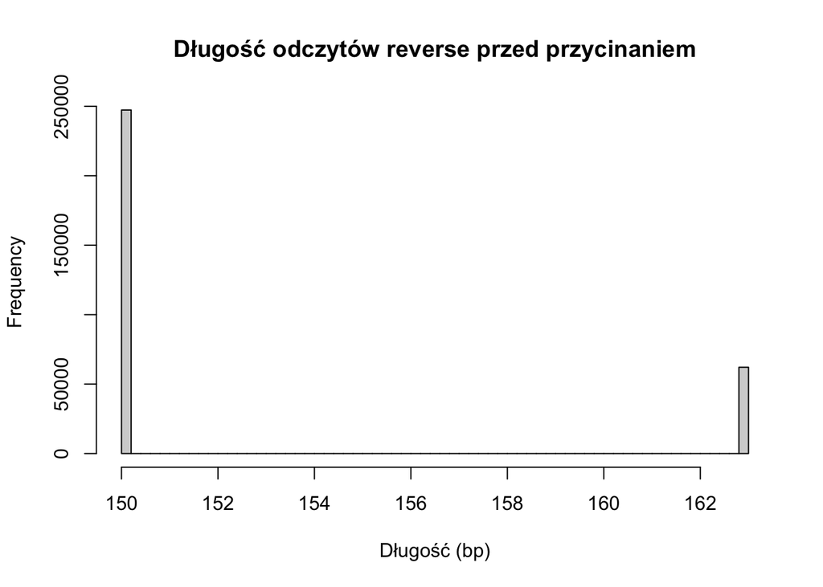

```r
   # Przed przycinaniem (odczyty reverse)
   hist(width(fq_reads2), breaks = 50, main = "Długość odczytów reverse przed przycinaniem", xlab = "Długość (bp)")
```

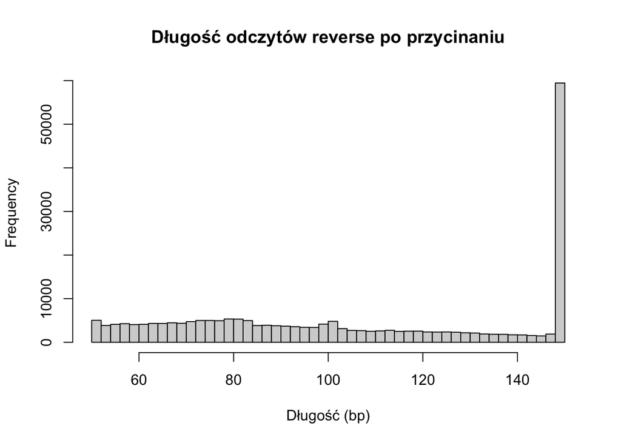

```r
   # Po przycinaniu (odczyty forward)
   hist(width(filtered_reads2), breaks = 50, main = "Długość odczytów reverse po przycinaniu", xlab = "Długość (bp)")
```

- Porównaj histogramy i opisz, jak przycinanie wpłynęło na długość odczytów.

##Wykrywanie i usuwanie sekwencji adapterów**

1. Zdefiniuj sekwencję adaptera (np. dla Illumina) i przytnij adaptery z odczytów:

```r
  library(Biostrings)
   adapter_seq <- DNAString("AGATCGGAAGAGC")
# Przycinanie adapterów z odczytów forward:
trimmed_reads1_adapt <- trimLRPatterns(
  Lpattern = adapter_seq,
  subject = filtered_reads1
)

# Defuniujemy odczyty po przycięciu adapterów:
filtered_reads1 <- trimmed_reads1_adapt

# Przycinanie adapterów z odczytów reverse:
trimmed_reads2_adapt <- trimLRPatterns(
  Lpattern = adapter_seq,
  subject = filtered_reads2
)

# Defuniujemy odczyty po przycięciu adapterów:
filtered_reads2 <- trimmed_reads2_adapt
```

2. Sprawdź efekty przycinania:

```r
# Porównaj długości przed i po przycięciu adapterów
length(filtered_reads1)
```

```
## [1] 248565
```

```r
length(trimmed_reads1)
```

```
## [1] 284123
```

```r
length(filtered_reads2)
```

```
## [1] 223516
```

```r
length(trimmed_reads2)
```

```
## [1] 273668
```

```r
# Sprawdź ile odczytów zostało zmodyfikowanych
   sum(width(filtered_reads1) < width(trimmed_reads1))
```

```
## [1] 120191
```

```r
   sum(width(filtered_reads2) < width(trimmed_reads2))
```

```
## [1] 110400
```

- Przytnij odczyty zawierające adaptery i sprawdź, ile odczytów zostało zmodyfikowanych.

```r
Seq1mod<-284123-248565
print(Seq1mod)
```

```
## [1] 35558
```

```r
Seq2mod<-273668-223516
print (Seq2mod)
```

```
## [1] 50152
```

##Ponowna kontrola jakości po usunięciu adapterów**

1. Zapisz odczyty po usunięciu adapterów:

```r
   writeFastq(filtered_reads1, "/Users/arturbalicki/Desktop/Studia/Magisterskie/ecoli_simulated1_final.fq")
   writeFastq(filtered_reads2, "/Users/arturbalicki/Desktop/Studia/Magisterskie/ecoli_simulated2_final.fq")
```

2. Wygeneruj ostateczne raporty QC:

```r
   qa_results1_final <- qa("/Users/arturbalicki/Desktop/Studia/Magisterskie/ecoli_simulated1_final.fq", type = "fastq")
   report(qa_results1_final, dest = "/Users/arturbalicki/Desktop/Studia/Magisterskie/QA_report_read1_final")
```

```
## [1] "/Users/arturbalicki/Desktop/Studia/Magisterskie/QA_report_read1_final/index.html"
```

```r
   qa_results2_final <- qa("/Users/arturbalicki/Desktop/Studia/Magisterskie/ecoli_simulated2_final.fq", type = "fastq")
   report(qa_results2_final, dest = "/Users/arturbalicki/Desktop/Studia/Magisterskie/QA_report_read2_final")
```

```
## [1] "/Users/arturbalicki/Desktop/Studia/Magisterskie/QA_report_read2_final/index.html"
```

##Dokumentacja i raportowanie wyników**

1. Uzupełnij dokument R Markdown (`QC_and_Trimming_Report.Rmd`) o:
   - Kody R użyte w przycinaniu i filtracji.
   - Wyniki w postaci wykresów i tabel.
   - Interpretację wyników i wnioski.
2. Wygeneruj raport w formacie HTML lub PDF.

**Zadanie do wykonania:**

- Przygotuj przejrzysty i kompletny raport z procesu przycinania i filtracji.

## **Podsumowanie**

Przeprowadziliśmy pełny proces kontroli jakości oraz przycinania i filtracji danych NGS z wykorzystaniem symulowanych odczytów **Escherichia coli**. Dzięki temu przećwiczyliśmy w praktyce:

- Wczytywanie i podstawową analizę danych sekwencyjnych w R.
- Generowanie i interpretację raportów QC.
- Przycinanie odczytów na podstawie jakości i usuwanie sekwencji adapterów.
- Dokumentację i raportowanie wyników analiz bioinformatycznych.